# Finding Patterns in Public GIS Data

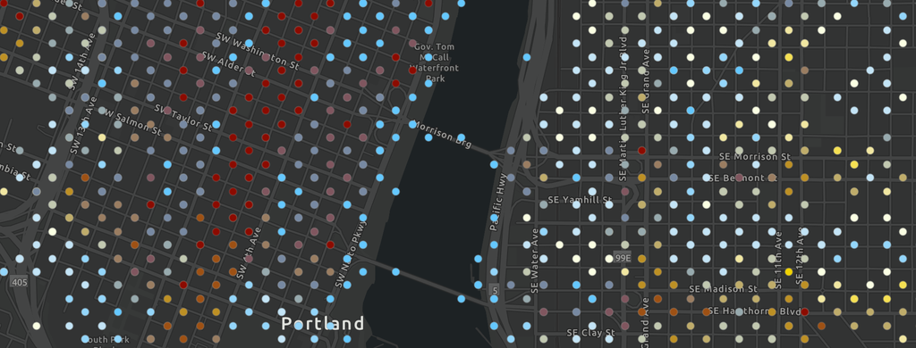

# Overview

## What?

**Find out how many patterns can we discover in 20 minutes** with public GIS data

## How?

- 1) Analyze a handful of **quantitative relationships** between our datases
- 2) Then transform those relationships into a **spatial relationships**

### In Python!

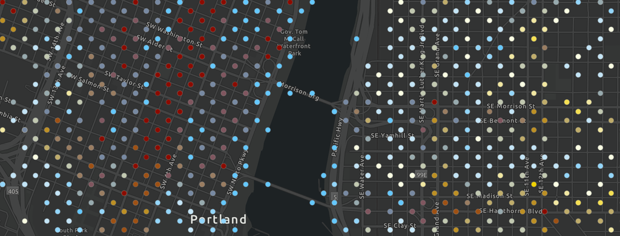

`https://developers.arcgis.com/python/`

# What data are we using?

| **Public data** \ *Data Type* | *Transit* | *Spatial* | *Time* | *Real-time* | *Socio-economic* |
| --- | --- | --- | --- | --- | --- |
| **Scooter trip data (counts, 2018)**PDOT | Yes | Yes | No | No | No |
| **GTFS static data**Trimet | Yes | Yes | Yes | No | No |
| **GTFS live data**Trimet | Yes | Yes | Yes | Yes | No |
| **Vulnerability data** (Open Data PDX / ArcGIS Hub) | No | Yes | No | No | Yes |

## Exploring two different kinds of space

## Exploring

#### `feature space`

- or named data fields, like: `route_color`, `transit_id`, or `Rounded Trips`
- statistics(Exploratory: not predictive)

#### `geographical space`

- Portland, Oregon
- GIS

### Portland Department Of Transportation Scooter 2018 data

- The scooter data was collected at street intersections in Portland
- Scooter counts that travelled "nearby" (100 feet?) to intersections

```python
scooter_sdf.head()
```

|  | Hex X | Hex Y | Segment name | Rounded Trips | SHAPE |
| --- | --- | --- | --- | --- | --- |
| 0 | -122.66775 | 45.497078 | WILLAMETTE GREENWAY TRAIL | 900 | {"x": -122.66775, "y": 45.4970775, "spatialRef... |
| 1 | -122.66925 | 45.524791 | WILLAMETTE GREENWAY TRAIL | 15600 | {"x": -122.66925, "y": 45.5247905, "spatialRef... |
| 2 | -122.66925 | 45.522192 | WILLAMETTE GREENWAY TRAIL | 19600 | {"x": -122.66925, "y": 45.522192499999996, "sp... |
| 3 | -122.67000 | 45.492314 | WILLAMETTE GREENWAY TRAIL | 800 | {"x": -122.67, "y": 45.4923145, "spatialRefere... |
| 4 | -122.67000 | 45.467199 | WILLAMETTE GREENWAY TRAIL | 300 | {"x": -122.67, "y": 45.4671995, "spatialRefere... |

## Ok, let's get to work looking for patterns

### Example: Scooter trip counts by Portland city segments

## Next: Add spatial (`SHAPE`) columns to our `DataFrame`s

**Transform our `pandas.DataFrame`s into `SpatialDataFrame`s**

- *Best Practice for more than `1k` features*
- *Easy to import data with an `arcgis.GIS` object:* `gis.content.import_data`

```
scooter_sdf = arcgis.features.GeoAccessor.from_xy(scooter_df, 'Hex X', 'Hex Y')
```

```python
scooter_sdf.head()
```

|  | Hex X | Hex Y | Segment name | Rounded Trips | SHAPE |
| --- | --- | --- | --- | --- | --- |
| 0 | -122.66775 | 45.497078 | WILLAMETTE GREENWAY TRAIL | 900 | {"x": -122.66775, "y": 45.4970775, "spatialRef... |
| 1 | -122.66925 | 45.524791 | WILLAMETTE GREENWAY TRAIL | 15600 | {"x": -122.66925, "y": 45.5247905, "spatialRef... |
| 2 | -122.66925 | 45.522192 | WILLAMETTE GREENWAY TRAIL | 19600 | {"x": -122.66925, "y": 45.522192499999996, "sp... |
| 3 | -122.67000 | 45.492314 | WILLAMETTE GREENWAY TRAIL | 800 | {"x": -122.67, "y": 45.4923145, "spatialRefere... |
| 4 | -122.67000 | 45.467199 | WILLAMETTE GREENWAY TRAIL | 300 | {"x": -122.67, "y": 45.4671995, "spatialRefere... |

```python
trips_by_segment.sort_values('Rounded Trips')[::-1][:5]
```

| Segment name | Rounded Trips |
| --- | --- |
| HAWTHORNE BRG | 18300 |
| SW HARBOR WAY | 16066 |
| SW MILL STREET CIR | 15900 |
| SW ALDER ST-MORRISON BRG RAMP | 15700 |
| STEEL BRIDGE BIKE PATH | 13900 |

```python
segment_map = default_map(); segment_map
```

[figure not shown]

## Let's focus on `Rounded Trips`

### Pattern: Exponential increase in higher scooter trips

## Finding patterns in quantitative data

## `pandas.DataFrame.describe`

```python
scooter_df['Rounded Trips'].describe()
```

```
count    14663.000000
mean      1056.059469
std       2061.823073
min        100.000000
25%        200.000000
50%        400.000000
75%        900.000000
max      59300.000000
Name: Rounded Trips, dtype: float64
```

### Woah!

- `50%` of street intersections see less than `400` trips per year!
- Let's sort the scooter trip data from decreasing to increasing order, and plot it

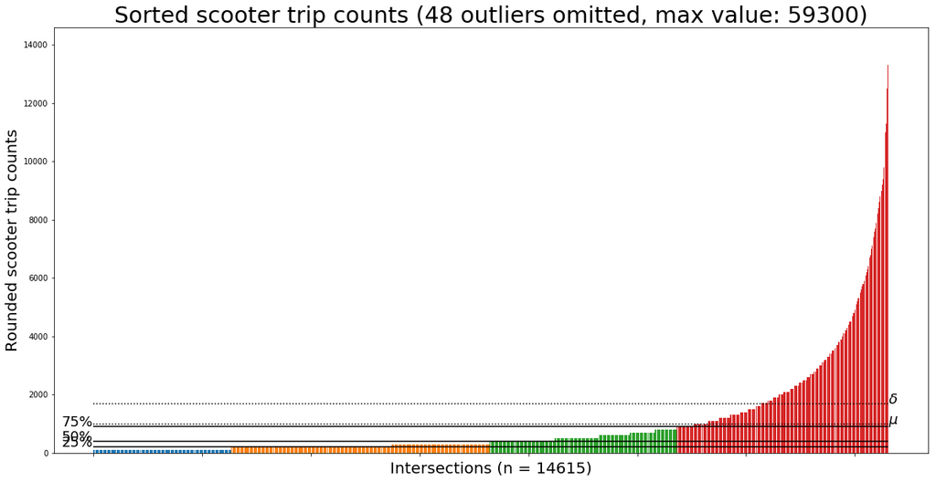

```python
plot_all_scooter_percentiles()
```

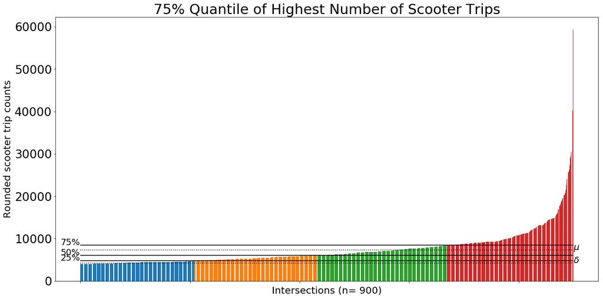

```python
plot_top_scooter_percentile()
```

### 75% Percentile

```python
# the 75% quantile stops
hot_scooter_sdf = scooter_sdf[scooter_sdf['Rounded Trips'] > 900]; hot_scooter_sdf['Rounded Trips'].describe()
```

```
count     3634.000000
mean      3289.598239
std       3222.250387
min       1000.000000
25%       1400.000000
50%       2200.000000
75%       3900.000000
max      59300.000000
Name: Rounded Trips, dtype: float64
```

### 93.75% Percentile

```python
hottest_scooter_sdf = scooter_sdf[scooter_sdf['Rounded Trips'] > 3900]; hottest_scooter_sdf['Rounded Trips'].describe()
```

```
count      900.000000
mean      7345.222222
std       4249.542206
min       4000.000000
25%       4800.000000
50%       6100.000000
75%       8400.000000
max      59300.000000
Name: Rounded Trips, dtype: float64
```

## We need to find patterns between scooter trip counts and other data

## Let's look for spatial patterns

### Another possibility: replace counts with relative frequencies

- Calculate the sum of all scooter trip counts: ($N$)
- Collect all the scooter counts for each intersection $i$: ($s_i$)
- Divide $s_i$ by $N$ to cacluate the *relative frequencies* of scooter trips at $i$: $\large s_i/N$, where $\sum s_i = N$

## Scooter Spatial Analysis

```python
scooter_map = default_map(); scooter_map
```

[figure not shown]

## Are scooter trip counts correlated with nearby transit stops?

### (Use ArcGIS Spatial Analysis service to run a nearby analysis)

## Next data set!

### The static GTFS feed data

**We'll only a subset of data from these files:**

- `stops.txt`
- `routes.txt`
- `shapes.txt`
- `trips.txt`

```python
trips_df.head()
```

|  | route_id | trip_id | shape_id |
| --- | --- | --- | --- |
| 0 | 1 | 9225445 | 419990 |
| 1 | 1 | 9225446 | 419990 |
| 2 | 1 | 9225447 | 419990 |
| 3 | 1 | 9225448 | 419990 |
| 4 | 1 | 9225449 | 419990 |

## `stops.txt`

```python
stops_df.head()
```

|  | stop_id | stop_lat | stop_lon |
| --- | --- | --- | --- |
| 0 | 3 | 45.419388 | -122.665197 |
| 1 | 6 | 45.420217 | -122.673070 |
| 2 | 7 | 45.420411 | -122.672680 |
| 3 | 8 | 45.363509 | -122.593886 |
| 4 | 9 | 45.384645 | -122.602873 |

## `routes.txt`

```python
routes_df.head()
```

|  | route_id | route_type | route_color |
| --- | --- | --- | --- |
| 0 | 1 | 3 | NaN |
| 1 | 2 | 3 | NaN |
| 2 | 4 | 3 | NaN |
| 3 | 6 | 3 | NaN |
| 4 | 8 | 3 | NaN |

## `shapes.txt`

```python
shapes_df.head()
```

|  | shape_id | shape_pt_lat | shape_pt_lon | shape_pt_sequence |
| --- | --- | --- | --- | --- |
| 0 | 419990 | 45.522879 | -122.677388 | 1 |
| 1 | 419990 | 45.522913 | -122.677396 | 2 |
| 2 | 419990 | 45.522988 | -122.677431 | 3 |
| 3 | 419990 | 45.523003 | -122.676486 | 4 |
| 4 | 419990 | 45.523002 | -122.676463 | 5 |

## `trips.txt`

```python
trips_df.head()
```

|  | route_id | trip_id | shape_id |
| --- | --- | --- | --- |
| 0 | 1 | 9225445 | 419990 |
| 1 | 1 | 9225446 | 419990 |
| 2 | 1 | 9225447 | 419990 |
| 3 | 1 | 9225448 | 419990 |
| 4 | 1 | 9225449 | 419990 |

There are four kinds of routes in Trimet and `891` routes:

|  | route type | route type | # of routes | color |
| --- | --- | --- | --- | --- |
| 0 | Tram, streetcar, or light rail | 81 | yellow |  |
| 2 | Rail | 9 | red |  |
| 3 | Bus | 792 | blue |  |
| 6 | Funicular | 9 | green |  |

```python
with open('nearby_results.geojson', 'w') as f:
    json.dump(arcgis.features.GeoAccessor(nearby_result_sdf[['Hex_Y', 'Hex_X', 'SHAPE', 'Point_Count']]).to_featureset().to_geojson, f)
```

## Are scooter trip counts correlated with nearby transit stop counts?

#### Summarize Nearby - Spatial Analysis

```
def calculate_nearby_stops(
    stops_layer,
    scooter_quantile_layers,
    near_type='Walking Distance', distances=[20.0], units='Meters'):

    nearby = OrderedDict()
    for title, layer in scooter_quantile_layers.items():
        kw = { 'sum_nearby_layer': layer, 'summary_layer': stops_layer,
            'near_type': near_type, 'distances': distances, 'units': units }
        nearby[title] = arcgis.features.analysis.summarize_nearby(**kw)
    return nearby
```

`stops_layer` is from static GTFS data

```
hottest_nearby = calculate_nearby_stops(stops_layer, hottest_scooter_layers)
```

```python
hottest_nearby[hottest_titles[3]]['result_layer'].query().sdf[['Point_Count', 'Rounded_Tr', 'Hex_X', 'Hex_Y', 'SHAPE']].head()
```

|  | Point_Count | Rounded_Tr | Hex_X | Hex_Y | SHAPE |
| --- | --- | --- | --- | --- | --- |
| 0 | 2 | 4000 | -122.68425 | 45.507470 | {"rings": [[[-13657146.4676, 5701955.0889], [-... |
| 1 | 0 | 9800 | -122.67225 | 45.500541 | {"rings": [[[-13655796.4738, 5700849.2861], [-... |
| 2 | 1 | 4500 | -122.66175 | 45.515264 | {"rings": [[[-13654671.4789, 5703203.740400001... |
| 3 | 0 | 5200 | -122.66400 | 45.517429 | {"rings": [[[-13654871.4779, 5703489.171099998... |
| 4 | 0 | 5100 | -122.69250 | 45.518295 | {"rings": [[[-13658071.4633, 5703667.569799997... |

### Result of summarize nearby task: transit stop counts near scooter intersections

```python
nearby_result_map = default_map(legend=True, basemap='dark-gray-vector'); nearby_result_map
```

[figure not shown]

## Easy to combine our nearby transit stop data

```python
from functools import reduce
index = ['Hex_X', 'Hex_Y']
columns = ['Point_Count', 'Rounded_Tr', 'Hex_X', 'Hex_Y']
fn = lambda l, r: pandas.concat([l.set_index(index), r.set_index(index)]).reset_index()

nearby_dfs = [nearby_result['result_layer'].query().sdf[columns] for nearby_result in hottest_nearby.values()]
combined_nearby_df = reduce(lambda l,r: fn(l, r), nearby_dfs).sort_values('Rounded_Tr')
combined_nearby_sdf = arcgis.features.GeoAccessor.from_xy(combined_nearby_df, 'Hex_X', 'Hex_Y')
```

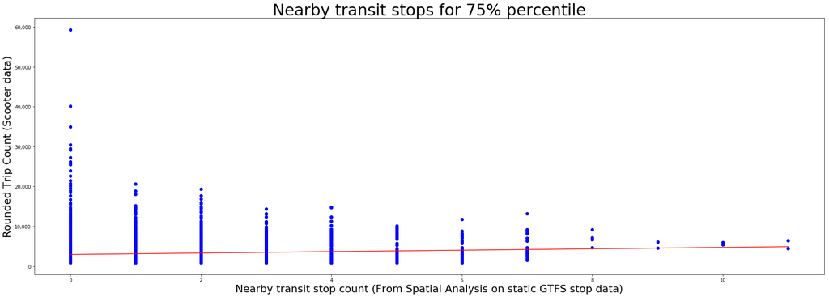

```python
scatter_plot_nearby_results(combined_nearby_sdf, 'Nearby transit stops for 75% percentile', 'Nearby transit stop count (From Spatial Analysis on static GTFS stop data)', 'Rounded Trip Count (Scooter data)')
```

## How are scooter trip and transit stop counts related spatially?

```python
nearby_map = default_map(); nearby_map.basemap = 'dark-gray-vector'; nearby_map
```

[figure not shown]

## Scooter trip centroids (the "centers" of scooter trip hotspots)

- Centroid on left: 93.75% percentile scooter trips ("hottest")
- Centroid on right: 75% percentile scooter trips ("hot")

```python
def calculate_distance_column(sdf, centroid_point):
    sdf = arcgis.features.GeoAccessor.from_xy(sdf, 'Hex_X', 'Hex_Y')
    return sdf['SHAPE'].apply(lambda s: s.distance_to(centroid_point))
```

```python
# take the centroid of the
hottest_centroid = hottest_scooter_quant_dfs['4th'].spatial.centroid
combined_centroid = combined_nearby_sdf.spatial.centroid
centroid_point = arcgis.geometry.Point({'x': hottest_centroid[0], 'y': hottest_centroid[1]})
combined_point = arcgis.geometry.Point({'x': combined_centroid[0], 'y': combined_centroid[1]})
```

```python
centroid_map = default_map(); centroid_map
```

[figure not shown]

## Pattern: between Distance from centroids and top percentile scooter trips

```
def calculate_distance_column(sdf, centroid_point):
    sdf = arcgis.features.GeoAccessor.from_xy(sdf, 'Hex_X', 'Hex_Y')
    return sdf['SHAPE'].apply(lambda s: s.distance_to(centroid_point))
```

## Pattern: Relationship between Scooter trips and distance to "hottest" centroids from 4th quantile

```python
combined_nearby_sdf.head()
```

|  | Hex_X | Hex_Y | Nearby Stops | Scooter Trips | SHAPE | dist_hottest | dist_combined |
| --- | --- | --- | --- | --- | --- | --- | --- |
| 0 | -122.68500 | 45.507903 | 1 | 900 | {"x": -122.685, "y": 45.507903, "spatialRefere... | 0.016385 | 0.029124 |
| 433 | -122.63325 | 45.516130 | 1 | 900 | {"x": -122.63325, "y": 45.51613, "spatialRefer... | 0.043057 | 0.027298 |
| 432 | -122.63175 | 45.516130 | 0 | 900 | {"x": -122.63175, "y": 45.51613, "spatialRefer... | 0.044546 | 0.028759 |
| 428 | -122.63400 | 45.519161 | 0 | 900 | {"x": -122.634, "y": 45.519161, "spatialRefere... | 0.042031 | 0.026010 |
| 422 | -122.62875 | 45.512666 | 2 | 900 | {"x": -122.62875, "y": 45.512666, "spatialRefe... | 0.048044 | 0.032564 |

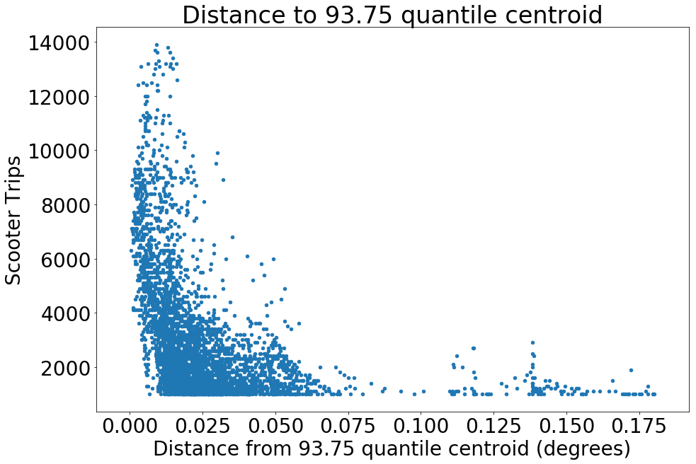

```python
plot_hottest_dist_centroid()
```

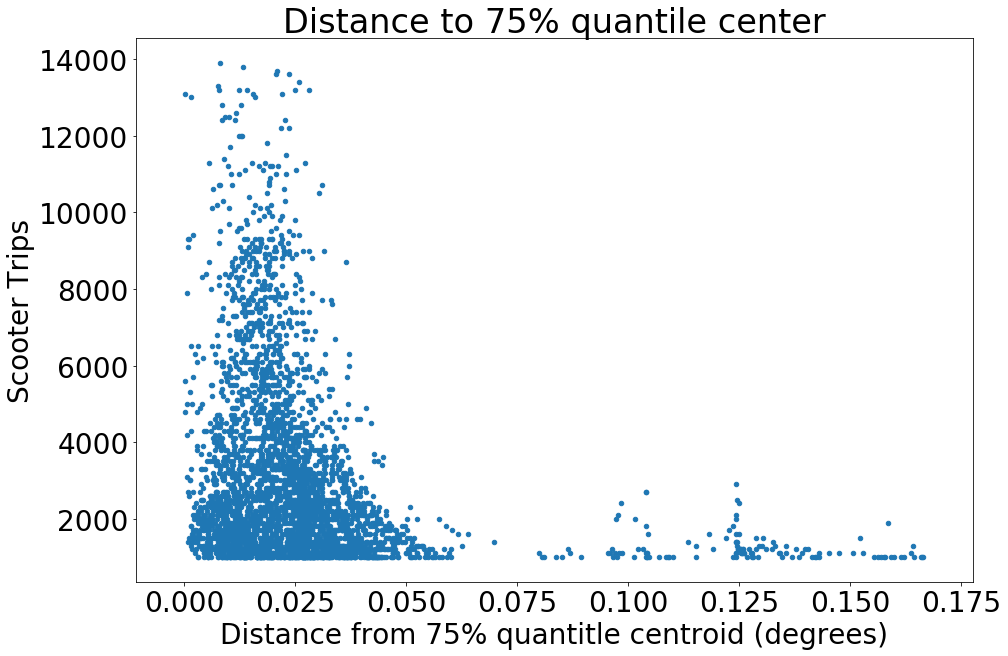

```python
plot_hot_dist_centroid()
```

## But again, we're leaving out the spatial component!

```python
combined_nearby_map = default_map(legend=True, basemap='dark-gray-vector');  combined_nearby_map
```

[figure not shown]

### Scooter trip data isn't uniformly decreasing

[figure not shown]

## What could explain anomalies in the distance to center / scooter trip count relationship?

### Idea: Population Density

#### Meausred by congestion

**Use LIVE GTFS data** for bus and rail delay times at the intersections from the scooter data

### Real-time GTFS vehicle feeds (Trimet - Developer AppID required)

```
import requests, json
appid = 'copy and paste your app id here'
vehicle_url = 'https://developer.trimet.org/ws/v2/vehicles'
r = requests.get(f'{vehicle_url}?appID={appid}')
with open ('gtfs_current_vehicle_locs.json', 'w') as f:
    json.dump(r.json(), f)
```

```python
live_data_sdf = arcgis.features.GeoAccessor.from_xy(live_data_df, x_column='longitude', y_column='latitude')
```

```python
live_data_sdf.head()
```

|  | delay | inCongestion | lastLocID | lastStopSeq | latitude | longitude | nextLocID | nextStopSeq | queryTime | routeNumber | serviceDate | tripID | type | SHAPE |
| --- | --- | --- | --- | --- | --- | --- | --- | --- | --- | --- | --- | --- | --- | --- |
| 0 | -282.0 | None | 9829.0 | 29.0 | 45.510767 | -122.853044 | 9832.0 | 30.0 | 2019-08-09 01:15:55.572 | 100 | 1565247600000 | 9290901 | rail | {"x": -122.8530443, "y": 45.5107671, "spatialR... |
| 1 | -57.0 | None | 8384.0 | 9.0 | 45.520097 | -122.682493 | 9757.0 | 10.0 | 2019-08-09 01:15:55.572 | 100 | 1565247600000 | 9290896 | rail | {"x": -122.6824928, "y": 45.520097, "spatialRe... |
| 2 | -90.0 | None | 8373.0 | 16.0 | 45.533305 | -122.622780 | 8374.0 | 17.0 | 2019-08-09 01:15:55.572 | 100 | 1565247600000 | 9290899 | rail | {"x": -122.6227801, "y": 45.5333049, "spatialR... |
| 3 | -10.0 | None | 11512.0 | 33.0 | 45.567551 | -122.682152 | 11513.0 | 34.0 | 2019-08-09 01:15:55.572 | 100 | 1565247600000 | 9289938 | rail | {"x": -122.6821522, "y": 45.5675513, "spatialR... |
| 4 | 16.0 | None | 10121.0 | 22.0 | 45.509377 | -122.778549 | 9624.0 | 23.0 | 2019-08-09 01:15:55.572 | 100 | 1565247600000 | 9290900 | rail | {"x": -122.778549, "y": 45.5093773, "spatialRe... |

## Non-spatial pattern: delay averages over time

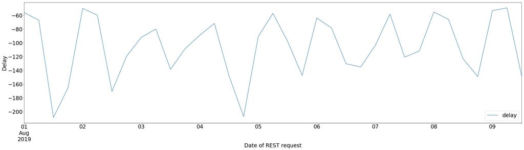

```python
plot_delay_averages_over_time()
```

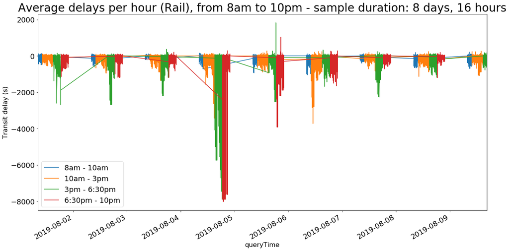

```python
plot_average_delays_hist(live_data_sdf, query='rail')
```

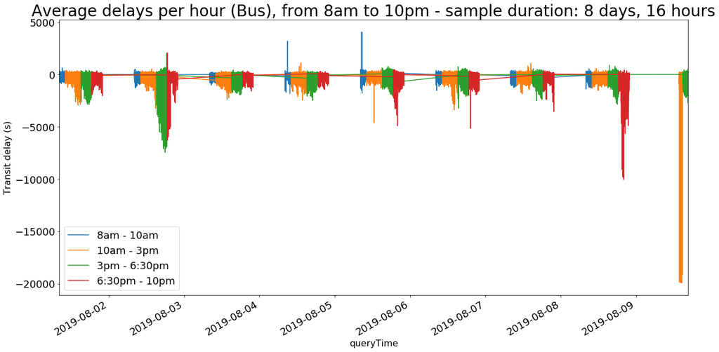

```python
plot_average_delays_hist(live_data_sdf, query='bus')
```

### How?

- **`trip_id` from `trips.txt` and `tripID` from the** live **GTFS data**

```python
bus_live_data_df.head()
```

|  | index | delay | inCongestion | lastLocID | lastStopSeq | latitude | longitude | nextLocID | nextStopSeq | queryTime | routeNumber | serviceDate | tripID | type | SHAPE |
| --- | --- | --- | --- | --- | --- | --- | --- | --- | --- | --- | --- | --- | --- | --- | --- |
| 43 | 43 | 0.0 | False | NaN | NaN | 45.529998 | -122.653649 | 13119.0 | 1.0 | 2019-08-09 01:15:55.572 | 98 | 1565247600000 | 9288967 | bus | {"x": -122.6536488, "y": 45.5299979, "spatialR... |
| 44 | 44 | 0.0 | False | NaN | NaN | 45.588037 | -122.592952 | 13504.0 | 1.0 | 2019-08-09 01:15:55.572 | 13 | 1565247600000 | 9277991 | bus | {"x": -122.5929517, "y": 45.5880373, "spatialR... |
| 45 | 45 | -36.0 | False | NaN | NaN | 45.530347 | -122.667890 | 13754.0 | 1.0 | 2019-08-09 01:15:55.572 | 98 | 1565247600000 | 9288236 | bus | {"x": -122.6678903, "y": 45.5303465, "spatialR... |
| 46 | 46 | 0.0 | False | 2957.0 | 1.0 | 45.569373 | -122.577764 | 13504.0 | 2.0 | 2019-08-09 01:15:55.572 | 13 | 1565247600000 | 9277682 | bus | {"x": -122.5777637, "y": 45.5693729, "spatialR... |
| 51 | 51 | 0.0 | False | NaN | NaN | 45.518575 | -123.115405 | 146.0 | 1.0 | 2019-08-09 01:15:55.572 | 57 | 1565247600000 | 9283201 | bus | {"x": -123.1154054, "y": 45.518575, "spatialRe... |

```python
bus_live_delay_trip_id_df = bus_live_data_df[['delay', 'tripID']].dropna()
bus_live_delay_trip_id_df['tripID'] = bus_live_delay_trip_id_df['tripID'].apply(int)
rail_live_delay_trip_id_df = rail_live_data_df[['delay', 'tripID']].dropna()
rail_live_delay_trip_id_df['tripID'] = rail_live_delay_trip_id_df['tripID'].apply(int)
```

```python
bus_live_delay_trip_id_df.head()
```

|  | delay | tripID |
| --- | --- | --- |
| 43 | 0.0 | 9288967 |
| 44 | 0.0 | 9277991 |
| 45 | -36.0 | 9288236 |
| 46 | 0.0 | 9277682 |
| 51 | 0.0 | 9283201 |

```python
rail_trip_df.head()
```

|  | route_id | trip_id | shape_id |
| --- | --- | --- | --- |
| 25762 | 90 | 9237306 | 420471 |
| 25763 | 90 | 9237307 | 420470 |
| 25764 | 90 | 9237308 | 420470 |
| 25765 | 90 | 9237309 | 420470 |
| 25766 | 90 | 9237310 | 420470 |

## Let's examine our real-time delay data spatially

```python
transit_delay_bus = calculate_delay_transit_feature_collection(_type='bus'); transit_delay_bus.head()
```

|  | shape_id | count | delay avg | SHAPE |
| --- | --- | --- | --- | --- |
| 0 | 419990 | 35.0 | -62.657143 | {'paths': [[[-122.677388, 45.522878999999996],... |
| 1 | 419989 | 113.0 | -226.707965 | {'paths': [[[-122.677388, 45.522878999999996],... |
| 2 | 419993 | 136.0 | -15.661765 | {'paths': [[[-122.72188500000001, 45.47623], [... |
| 3 | 419992 | 75.0 | -183.920000 | {'paths': [[[-122.720277, 45.476213], [-122.71... |
| 4 | 419995 | 2383.0 | -92.931179 | {'paths': [[[-122.675301, 45.527756], [-122.67... |

```python
bus_delay_map = default_map(legend=True); bus_delay_map
```

[figure not shown]

```python
rail_delay_map = default_map(legend=True); rail_delay_map
```

[figure not shown]

## Combining quantitative and spatial patterns

```python
combined_analysis_map = default_map(); combined_analysis_map
```

[figure not shown]

```python
# add bus delay times
combined_analysis_map.add_layer(gis.content.get('469b7f7346784a00aa5f72b5448dcc4b'))
```

```python
combined_analysis_map.add_layer(gis.content.get('63bd79b44875493fbdec9ceb3b164648'))
```

```python
plot_combined_distance_to_center_map(combined_analysis_map)
```

```python
combined_analysis_map.basemap = 'dark-gray-vector'
```

## Adding socio-economic data to our analysis

- Open Data PDX: `https://gis-pdx.opendata.arcgis.com/datasets/vulnerability`
- ArcGIS Hub: `https://hub.arcgis.com/search?collection=Dataset`

### We just need a spatial column ...

```
pdx_districts = vulnerable_sdf[['OBJECTID', 'SHAPE']]

filters = {}
for _, row in pdx_districts.iterrows():
    polygon = arcgis.geometry.Polygon(dict(rings=row['SHAPE']['rings'], wkid='4326'))
    sr = arcgis.geometry.SpatialReference('4326')
    _filter = arcgis.geometry.filters.within(polygon, sr)
    filters[row['OBJECTID']] = _filter
```

```
data = {}
for object_id, _filter in filters.items():
    _layer = combined_nearby_layer.layers[0].query(filters=_filter)
    # import our data here
```

## github.com/ChrisFrenchPDX/portland-geodev-talk-2019